# R graphics for bioinformatics

Steve Rozen  
Duke Medical School  
sr110@duke.edu, steverozen@pm.me

2026-08-03

## Graphing concepts are more important than technical details

Graph Galeries

- !! Multilingual: https://www.data-to-viz.com/
- R https://r-graph-gallery.com/ (incl: https://r-graph-gallery.com/best-dataviz-packages.html)
- Python https://python-graph-gallery.com/
- References to many plotting systems: https://datavizcatalogue.com/index.html

In many cases you can ask a coding agent to adapt these plots to the data you are analyzing, but you still need to understand the concepts behind `ggplot`

# Example: use a coding agent to tanslate a `seaborn` example to `ggplot2`

## `seaborn.lineplot`: the Python original

[seaborn](https://seaborn.pydata.org/) is the most popular high-level plotting package in Python, built on top of `matplotlib`. The example below is from the seaborn gallery: mean functional magnetic resonance signal multiple time point per brain `region`, split by `event`.

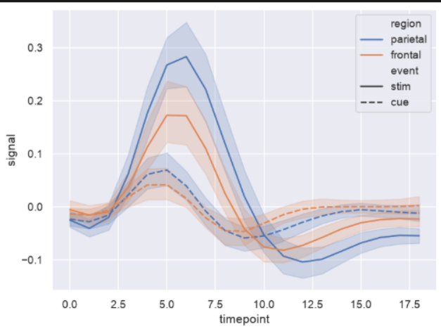

```python
import seaborn as sns
sns.set_theme(style="darkgrid")

fmri = sns.load_dataset("fmri")

sns.lineplot(
    x="timepoint", y="signal",
    hue="region", style="event",
    data=fmri)
```

(from https://seaborn.pydata.org/examples/errorband_lineplots.html)

## Prompt

```
I want to generate this plot in R using ggplot2: [Image #1], the python code is import seaborn as sns
sns.set_theme(style="darkgrid")

# Load an example dataset with long-form data
fmri = sns.load_dataset("fmri")

# Plot the responses for different events and regions
sns.lineplot(x="timepoint", y="signal",
             hue="region", style="event",
             data=fmri)
The data are in @fmri.csv
```

## `ggplot2` equivalent — code

```r
library(readr)
fmri <- read_csv("fmri.csv", show_col_types = FALSE)

gg_fmri <- ggplot(fmri, aes(x = timepoint, y = signal,
                            colour = region, linetype = event,
                            fill = region)) +
  stat_summary(fun.data = mean_cl_boot, geom = "ribbon",
               alpha = 0.2, colour = NA) +
  stat_summary(fun = mean, geom = "line", linewidth = 0.8) +
  scale_colour_manual(values = c(parietal = "#4C72B0", frontal = "#DD8452")) +
  scale_fill_manual(values   = c(parietal = "#4C72B0", frontal = "#DD8452")) +
  scale_linetype_manual(values = c(stim = "solid", cue = "dashed")) +
  theme_gray(base_size = 12) +
  theme(panel.background = element_rect(fill = "#EAEAF2", colour = NA),
        panel.grid.major = element_line(colour = "white"),
        panel.grid.minor = element_line(colour = "white", linewidth = 0.3),
        legend.key       = element_rect(fill = "#EAEAF2")) +
  labs(x = "timepoint", y = "signal", colour = "region",
       linetype = "event", fill = "region")
```

## Comments on the ggplot2 translation

Notes from the coding agent:

- `stat_summary(mean_cl_boot)` matches seaborn’s default 95% bootstrap CI. For a faster approximation use `mean_cl_normal` (normal-theory CI) or `mean_se` (one SEM, narrower).
- The two manual scales for `colour` and `fill` use the seaborn “deep” palette hex codes so the ribbons match the lines.
- `theme_gray` plus the panel-background tweaks approximate seaborn’s `darkgrid` style. The remainder of the coding agent’s notes were hallucinated: “If you have the `ggthemes` package, `ggthemes::theme_solarized()` or the `seaborn` R package’s `theme_seaborn()` are alternatives, but the inline theme above avoids the extra dependency.”

Note that the python code is used several times in `seaborn` documentation and training material. The LLM probably saw it during training.

## `ggplot2` vs. `seaborn` — side by side

**ggplot2**

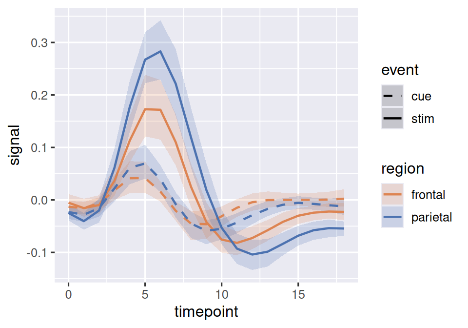

**seaborn**

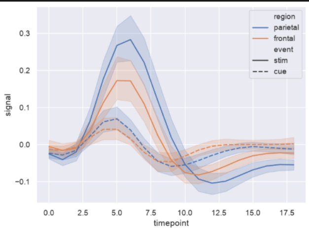

## For your future reference

Wilke, *Fundamentals of Data Visualization* https://clauswilke.com/dataviz/

Chang, 2026, *R Graphics Cookbook, 2nd ed* https://r-graphics.org/

Wickham et al., *R for Data Science, 2nd ed* https://r4ds.hadley.nz/

`plotnine` python package inspired by `ggplot2` https://plotnine.org/

Wickham, *ggplot2: Elegant Graphics for Data Analysis (3e)* https://ggplot2-book.org/

## About these examples

Most of these examples are from the draft chapters *First steps* and *Arranging plots* in the e-book Wickham, Navarro, and Pedersen, *ggplot2: Elegant Graphics for Data Analysis* (3rd ed.),

https://ggplot2-book.org/getting-started.html, https://ggplot2-book.org/arranging-plots.html, downloaded June 25, 2026.

We also re-use examples from Selva Prabhakaran’s [Complete ggplot2 Tutorial, Part 1](https://r-statistics.co/Complete-Ggplot2-Tutorial-Part1-With-R-Code.html).

For each example we keep the original **ggplot2** code and plot on one slide, then the **tidyplots** equivalent on the next.

## Main differences between ggplot2 and tidyplots

- **ggplot2** maps columns to aesthetics inside `aes()`, then stacks `geom_*()` and `scale_*()` layers with `+`.
- **tidyplots** pipes the data frame in, then chains `add_*()`, `adjust_*()`, and `remove_*()` verbs with the native pipe `|>`.

## Two recurring frictions

1. **No transformed expressions in mappings.** ggplot2 takes `aes(y = unemploy / pop)` or `colour = factor(cyl)`. tidyplots’ `tidyplot()` wants bare column names, so we precompute with `mutate()` first.
2. **No native verb for a few geoms** (frequency polygons, paths). For those we use the escape hatch `add(ggplot2::...)`, which drops a raw ggplot2 layer into a tidyplot.

## Setup

```r
library(ggplot2)        # the book's package
library(tidyplots)      # the package we translate each step into
library(dplyr)          # for the mutate()/filter() precompute steps
library(mgcv)           # for the GAM smoother example
data("mpg", package = "ggplot2")          # 234 car models
data("economics", package = "ggplot2")    # US economic time series
```

## The `mpg` miles-per-gallon example data

`mpg` is a `tibble` with info on car models, including engine displacement (`displ`), highway mileage (`hwy`), city mileage (`cty`), drivetrain (`drv`), etc.

```r
mpg
```

```
# A tibble: 234 × 11
   manufacturer model      displ  year   cyl trans drv     cty   hwy fl    class
   <chr>        <chr>      <dbl> <int> <int> <chr> <chr> <int> <int> <chr> <chr>
 1 audi         a4           1.8  1999     4 auto… f        18    29 p     comp…
 2 audi         a4           1.8  1999     4 manu… f        21    29 p     comp…
 3 audi         a4           2    2008     4 manu… f        20    31 p     comp…
 4 audi         a4           2    2008     4 auto… f        21    30 p     comp…
 5 audi         a4           2.8  1999     6 auto… f        16    26 p     comp…
 6 audi         a4           2.8  1999     6 manu… f        18    26 p     comp…
 7 audi         a4           3.1  2008     6 auto… f        18    27 p     comp…
 8 audi         a4 quattro   1.8  1999     4 manu… 4        18    26 p     comp…
 9 audi         a4 quattro   1.8  1999     4 auto… 4        16    25 p     comp…
10 audi         a4 quattro   2    2008     4 manu… 4        20    28 p     comp…
# ℹ 224 more rows
```

## Basic scatterplot — ggplot2

Every plot needs data (in this case the `mpg` `tibble`), an “`aes()`” (short for aesthetic mapping, which says which columns of `mpg` will be represented on the $x$ axis [column `displ` in the example below] and which one the $y$ axis [`hwy` – the highway miles per gallon], and at least one “`geom()`” [short for geometric object]).

```r
ggplot(mpg, aes(x = displ, y = hwy)) +   # data + x/y mapping
  geom_point()                           # draw points
```

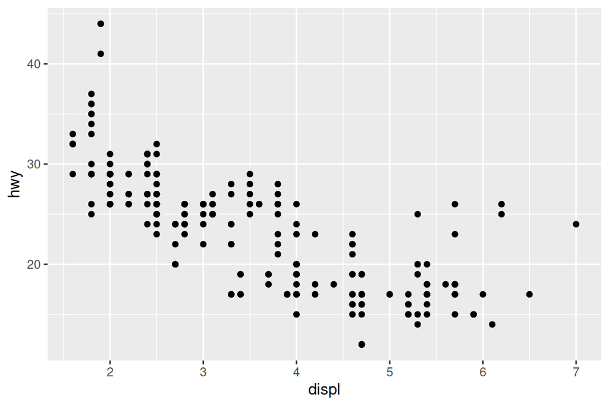

## Basic scatterplot — tidyplots

The mapping goes inside `tidyplot()`; points are `add_data_points()`. `|>` “redirects” `mpg` as the the first argument to `tidyplot`. The remaining arguments tell `tidyplot` what column to use for the $x$ axis and what column to use for the $y$ axis.

```r
mpg |>
  tidyplot(x = displ, y = hwy, width = NA, height = NA) |>
  add_data_points()
```

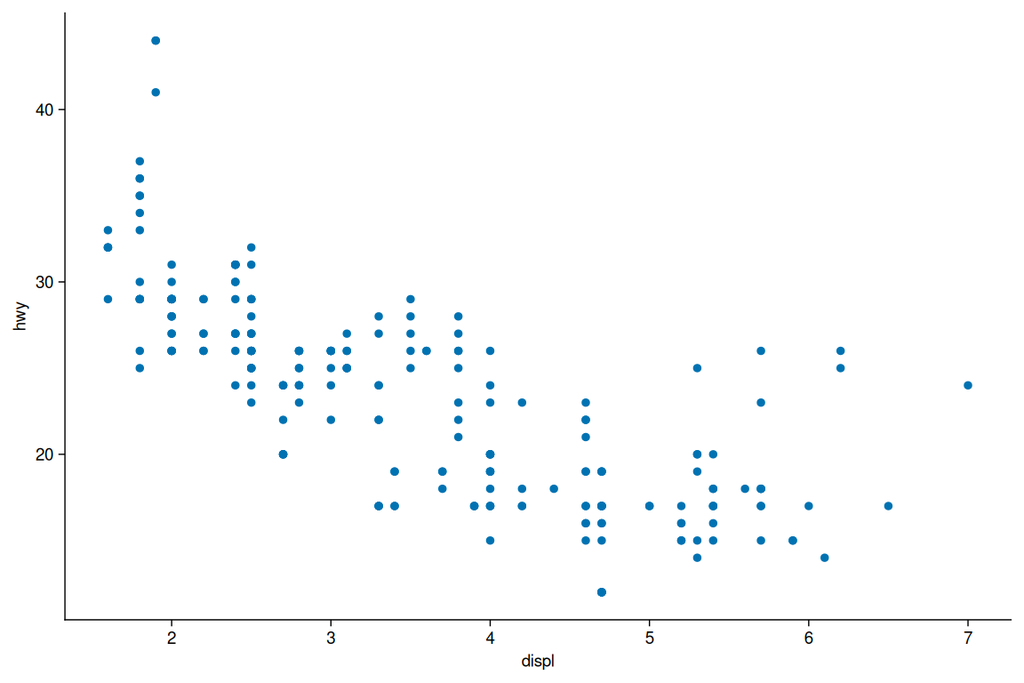

## Mapping colour to scatterplot — ggplot2

`aes(colour = class)` puts the variable in the mapping.

```r
ggplot(mpg, aes(displ, hwy, colour = class)) +
  geom_point()
```

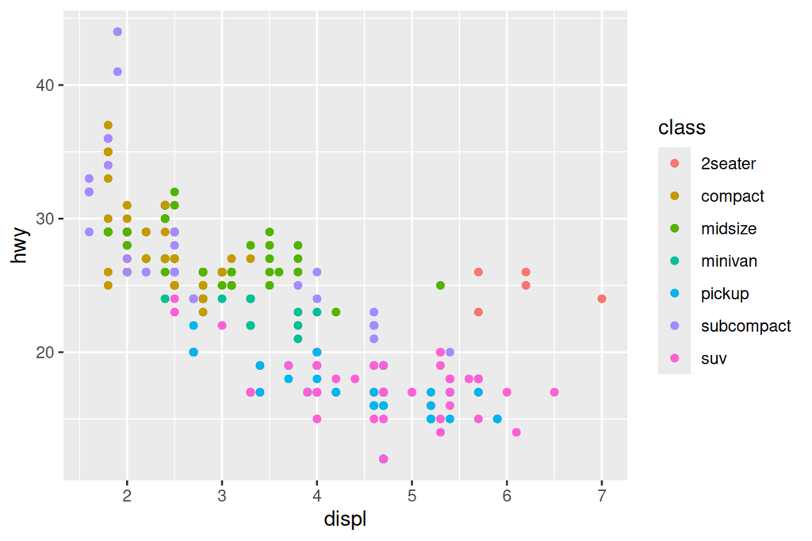

## Mapping colour to scatterplot — tidyplots

`color = class` goes inside `tidyplot()`.

```r
mpg |>
  tidyplot(x = displ, y = hwy, color = class, width = NA, height = NA) |>
  add_data_points()
```

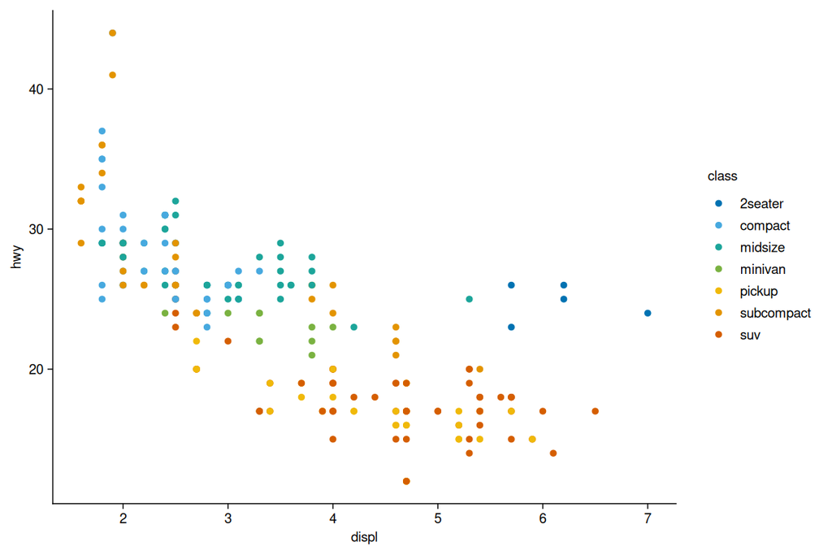

## Fixed colour — ggplot2

A constant colour is *not* an aesthetic, it goes *outside* `aes()`.

```r
ggplot(mpg, aes(displ, hwy)) +
  geom_point(colour = "blue")   # fixed colour, no legend
```

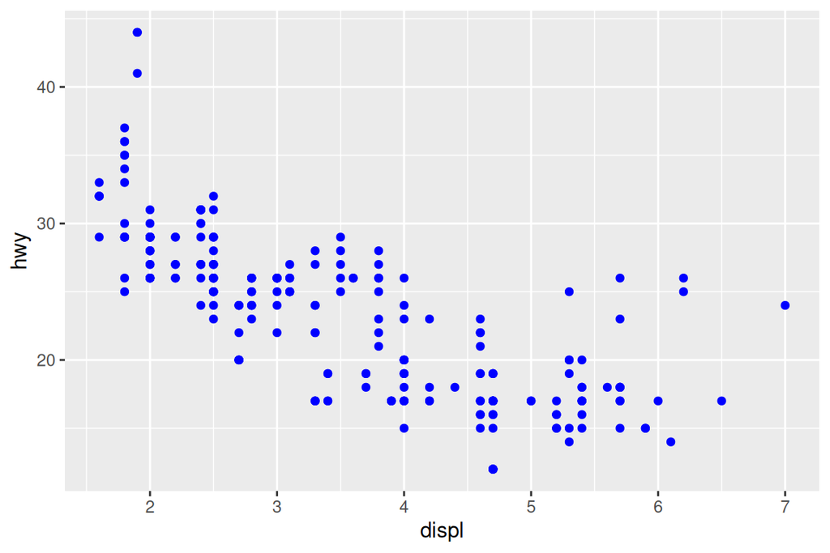

## Fixed colour — tidyplots

A plain argument to the geom verb, no legend.

```r
mpg |>
  tidyplot(x = displ, y = hwy, width = NA, height = NA) |>
  add_data_points(color = "blue")
```

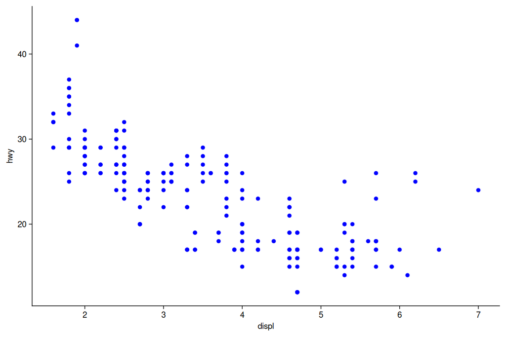

## Color by category + global fit — ggplot2

Points coloured by `state`, single global linear fit.

```r
gg <- ggplot(midwest <- ggplot2::midwest, aes(x = area, y = poptotal)) +
  geom_point(aes(col = state), size = 3) +
  geom_smooth(method = "lm", col = "firebrick", size = 2) +
  coord_cartesian(xlim = c(0, 0.1), ylim = c(0, 1000000)) +
  labs(title = "Area Vs Population", y = "Population", x = "Area")
gg
```

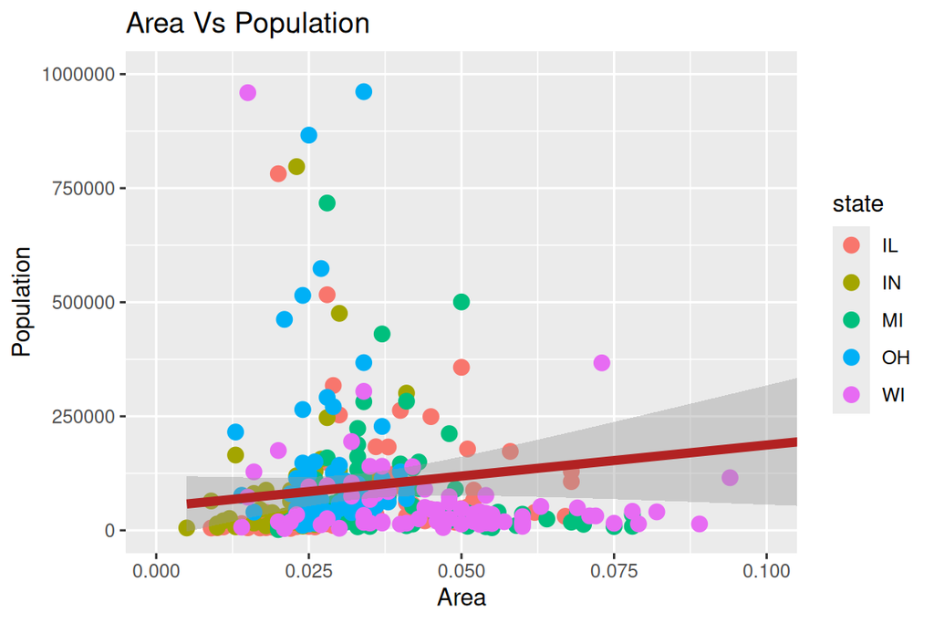

## Color by category + global fit — tidyplots first try (code)

`color = state` in `tidyplot()` is inherited by **every** later layer, so a naive `add_curve_fit()` fits **one line per state**, not the single global fit we wanted.

```r
tp_try <- midwest |>
  tidyplot(x = area, y = poptotal, color = state, width = NA, height = NA) |>
  add_data_points(size = 3) |>
  add_curve_fit(method = "lm", color = "firebrick") |>            # inherits color = state -> one fit per state
  add(ggplot2::coord_cartesian(xlim = c(0, 0.1), ylim = c(0, 1000000))) |>
  adjust_title("Area Vs Population") |>
  adjust_x_axis_title("Area") |>
  adjust_y_axis_title("Population")
```

## Color by category + global fit — tidyplots first try (plot)

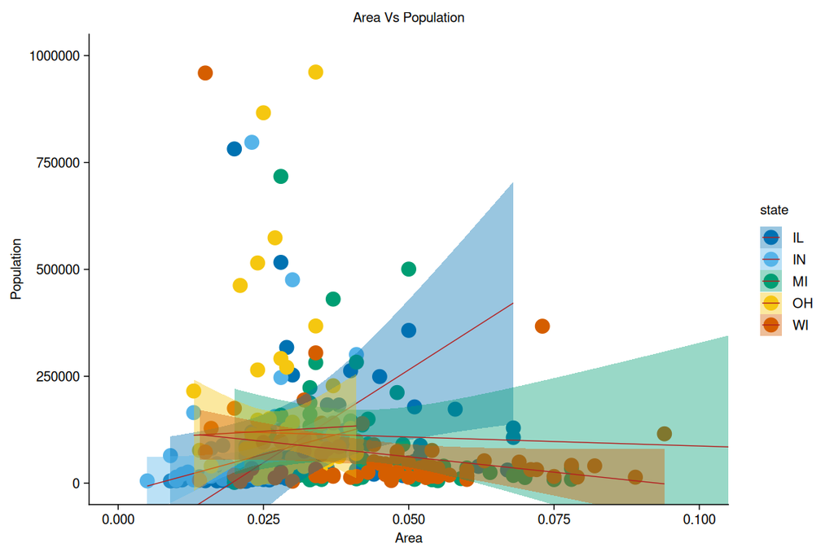

## Color by category + global fit — tidyplots fixed (code)

As we saw, `color = state` in `tidyplot()` is inherited by **every** later layer, so `add_curve_fit()` fits one line per state. We use the `add(ggplot2::...` escape hatch.

```r
tp <- midwest |>
  tidyplot(x = area, y = poptotal, color = state, width = NA, height = NA) |>
  add_data_points(size = 3) |>
  add(ggplot2::geom_smooth(ggplot2::aes(color = NULL, group = 1),
                           method = "lm", color = "firebrick", linewidth = 1)) |>
  add(ggplot2::coord_cartesian(xlim = c(0, 0.1), ylim = c(0, 1000000))) |>
  adjust_title("Area Vs Population") |>
  adjust_x_axis_title("Area") |>
  adjust_y_axis_title("Population")
```

## Color by category + global fit — tidyplots fixed (plot)

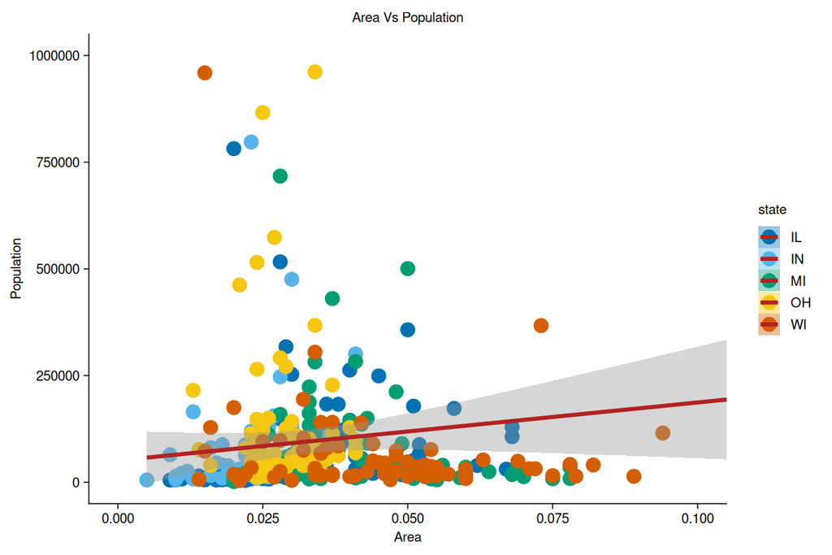

## Grouping by color different in `ggplot2` vs `tidyplot`

- In **ggplot2**, a `geom_smooth()` with a fixed `col = "firebrick"` outside `aes()` carries **no grouping**, so it fits one global line even when points are coloured by `state`.
- In **tidyplots**, the `color = state` set in `tidyplot()` is **global**, every statistical layer (`add_curve_fit()`, `add_mean_bar()`, …) inherits it and groups by `state` by default.
- To get a single fit, cancel the inherited grouping with `ggplot2::aes(color = NULL, group = 1)` via the escape hatch.
- If you actually want one fit per state, just write `add_curve_fit(method = "lm")` with no overrides. The ggplot2 equivalent moves `color = state` into the shared `aes()` so `geom_smooth()` inherits it.

## Faceting — ggplot2

`facet_wrap(~ class)` makes one panel per `class`, with shared scales.

```r
ggplot(mpg, aes(displ, hwy)) +
  geom_point() +
  facet_wrap(~ class)
```

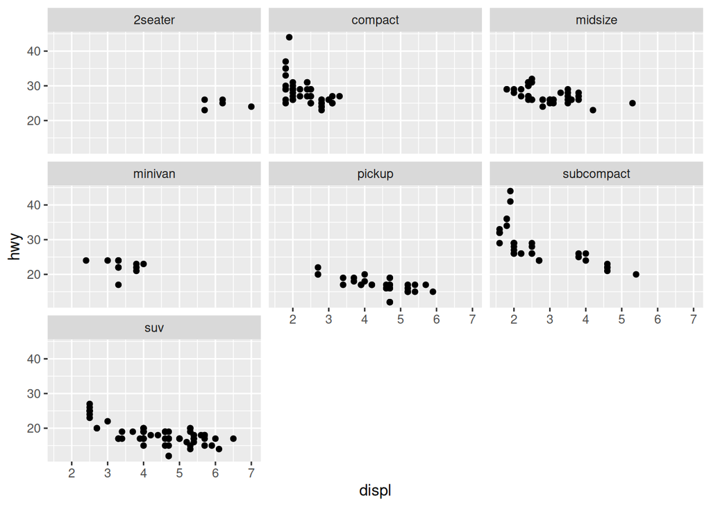

## Faceting — tidyplots

`split_plot()` free-scales each panel; the escape hatch `facet_wrap()` keeps ggplot2’s shared scales.

```r
mpg |>
  tidyplot(x = displ, y = hwy, width = NA, height = NA) |>
  add_data_points() |>
  add(ggplot2::facet_wrap(~ class))
```

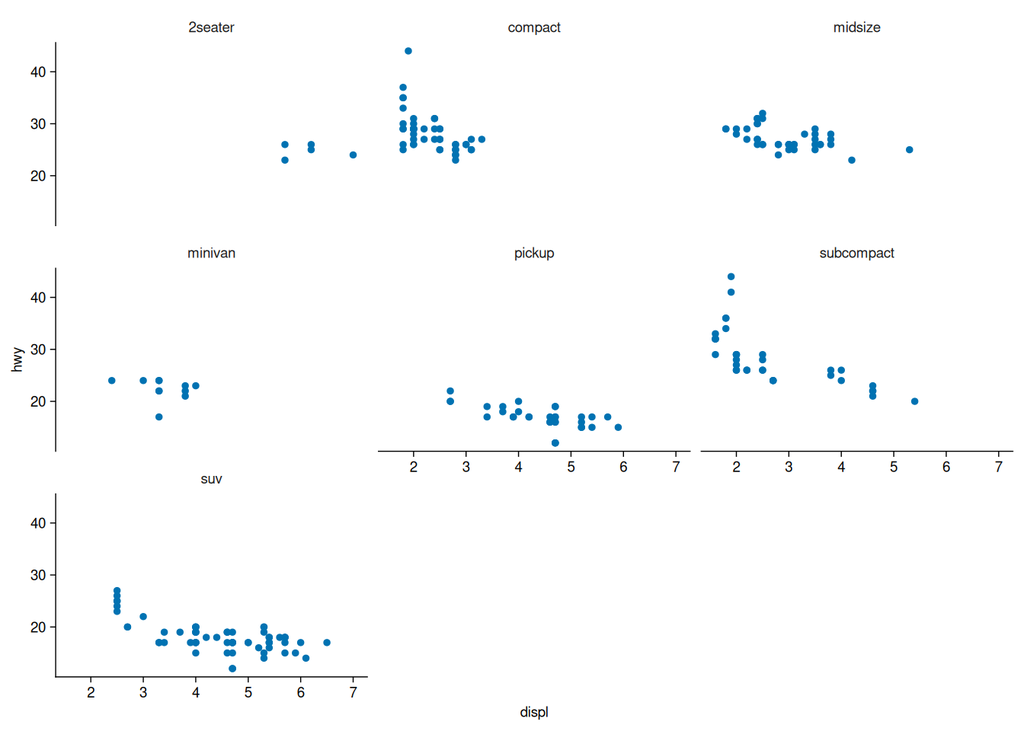

## Exercise

Generate this plot. How can you make it more intelligible?

```r
 ggplot(mpg, aes(displ, hwy, size = cyl, color = fl, shape=drv)) + geom_point()
```

## Fitting curves — ggplot2

```r
ggplot(mpg, aes(displ, hwy)) +
  geom_point() +
  geom_smooth()           # loess by default, with a ribbon
```

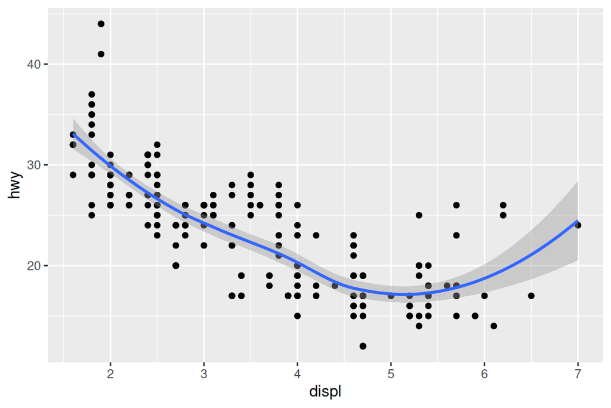

## Fitting curves — tidyplots

```r
mpg |>
  tidyplot(x = displ, y = hwy, width = NA, height = NA) |>
  add_data_points() |>
  add_curve_fit()         # loess by default, with a ribbon
```

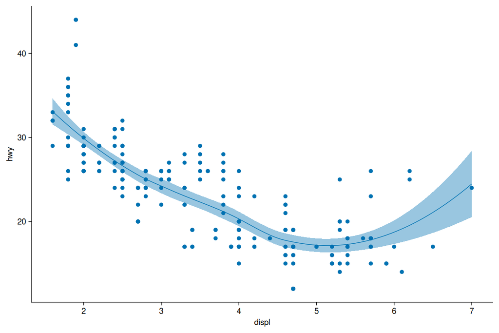

## Wigglier loess (`span`) — ggplot2

```r
ggplot(mpg, aes(displ, hwy)) +
  geom_point() +
  geom_smooth(span = 0.2)
```

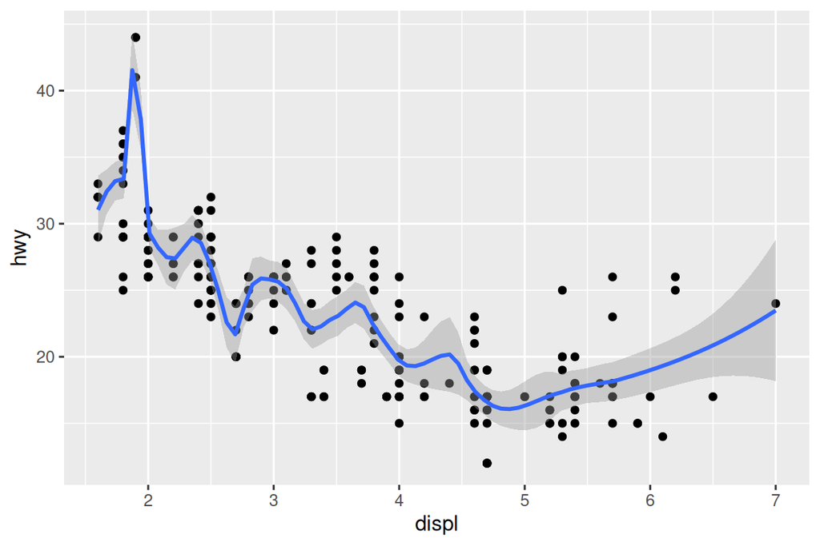

## Wigglier loess (`span`) — tidyplots

```r
mpg |>
  tidyplot(x = displ, y = hwy, width = NA, height = NA) |>
  add_data_points() |>
  add_curve_fit(span = 0.2)
```

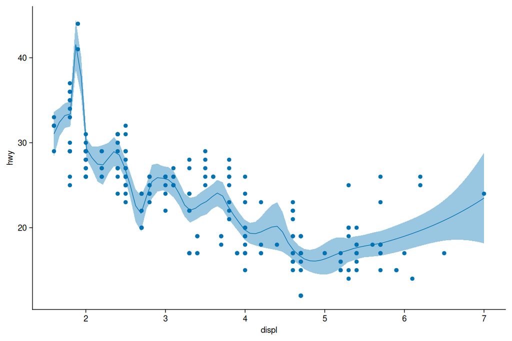

## GAM smoother — ggplot2

```r
ggplot(mpg, aes(displ, hwy)) +
  geom_point() +
  geom_smooth(method = "gam", formula = y ~ s(x))
```

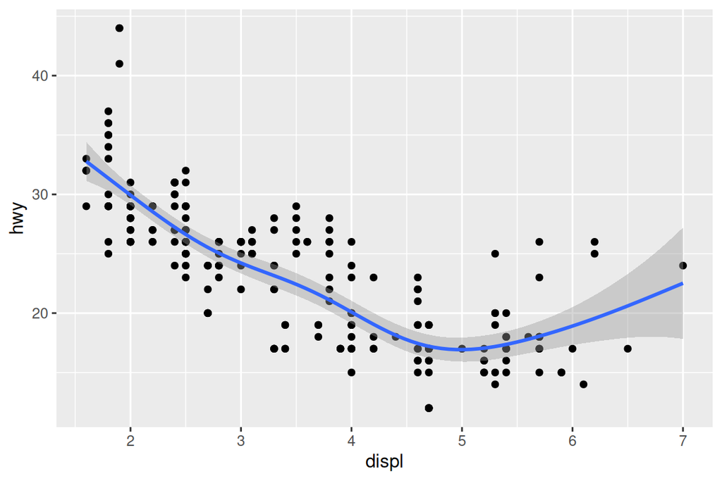

## GAM smoother — tidyplots

```r
mpg |>
  tidyplot(x = displ, y = hwy, width = NA, height = NA) |>
  add_data_points() |>
  add_curve_fit(method = "gam", formula = y ~ s(x))
```

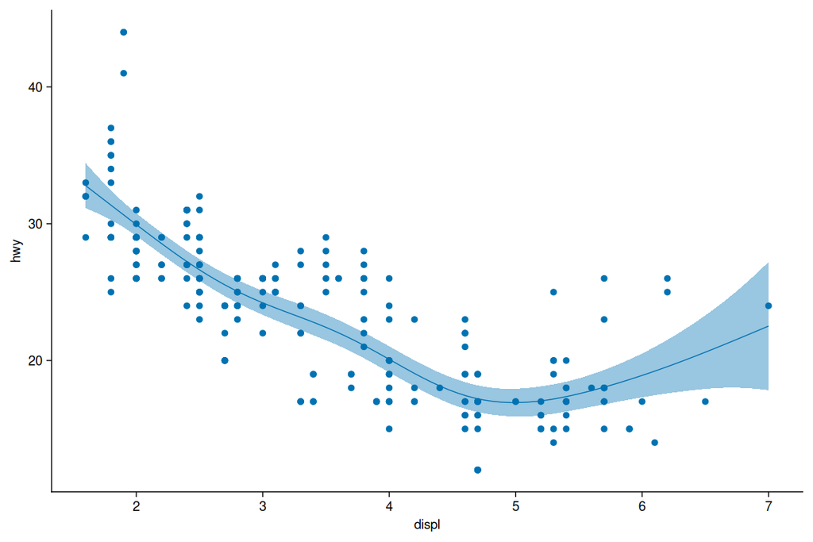

## Linear fit — ggplot2

```r
ggplot(mpg, aes(displ, hwy)) +
  geom_point() +
  geom_smooth(method = "lm")
```

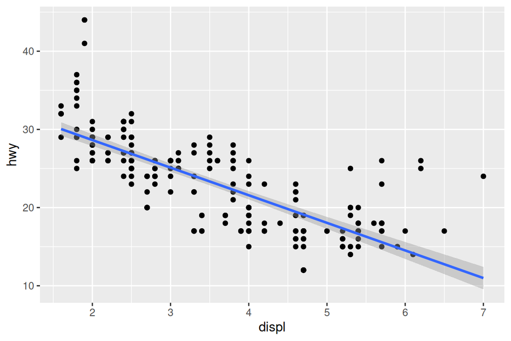

## Linear fit — tidyplots

```r
mpg |>
  tidyplot(x = displ, y = hwy, width = NA, height = NA) |>
  add_data_points() |>
  add_curve_fit(method = "lm")
```

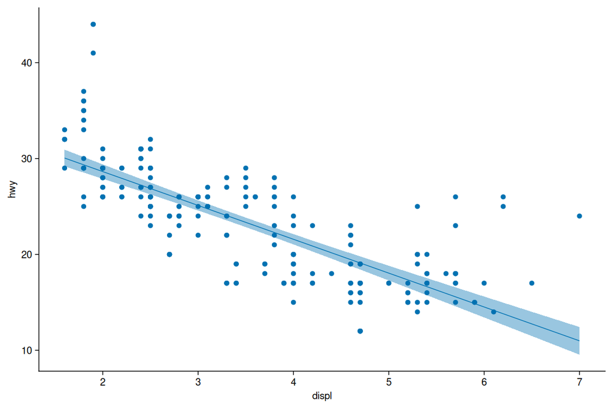

## Hidden points because of overplotting at discrete x — ggplot2

```r
ggplot(mpg, aes(drv, hwy)) +
  geom_point()
```

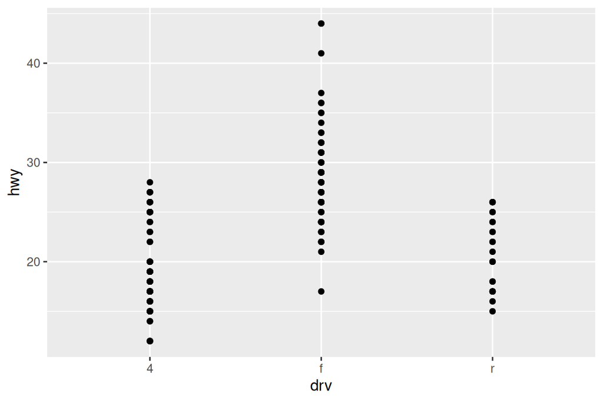

## Hidden points because of overplotting at discrete x — tidyplots

```r
mpg |>
  tidyplot(x = drv, y = hwy, width = NA, height = NA) |>
  add_data_points()
```

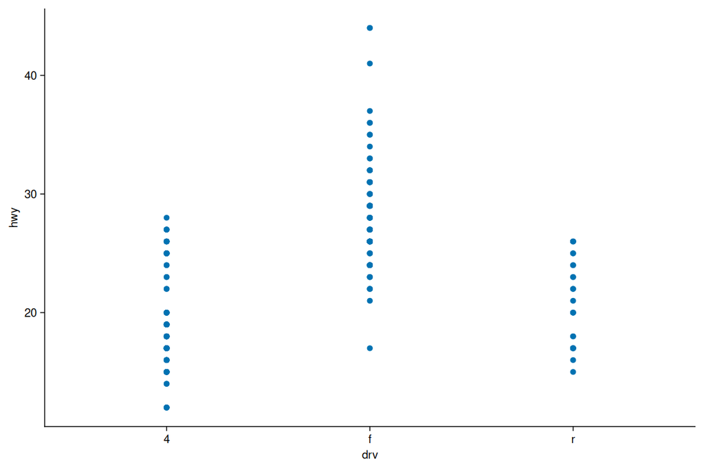

## The solution: jitter — ggplot2

```r
ggplot(mpg, aes(drv, hwy)) + geom_jitter()
```

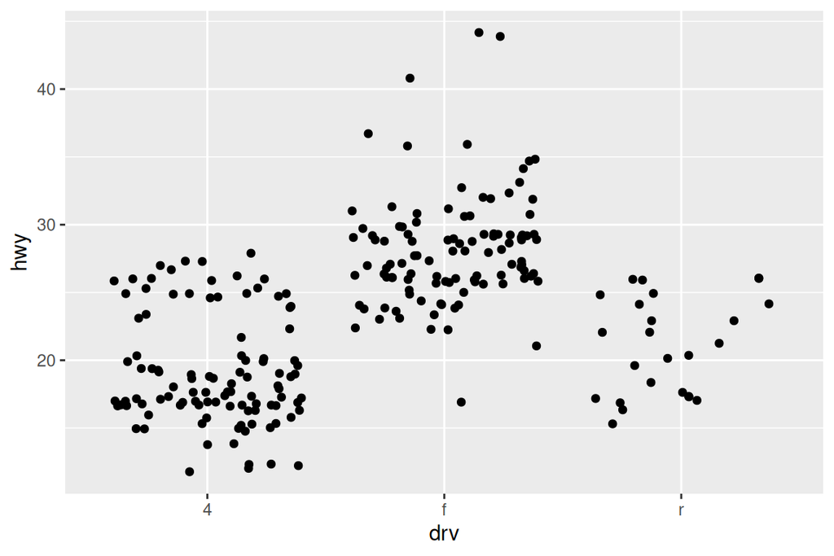

## The solution: jitter — tidyplots

```r
mpg |>
  tidyplot(x = drv, y = hwy, width = NA, height = NA) |>
  add_data_points_jitter(jitter_width = 0.8)
```

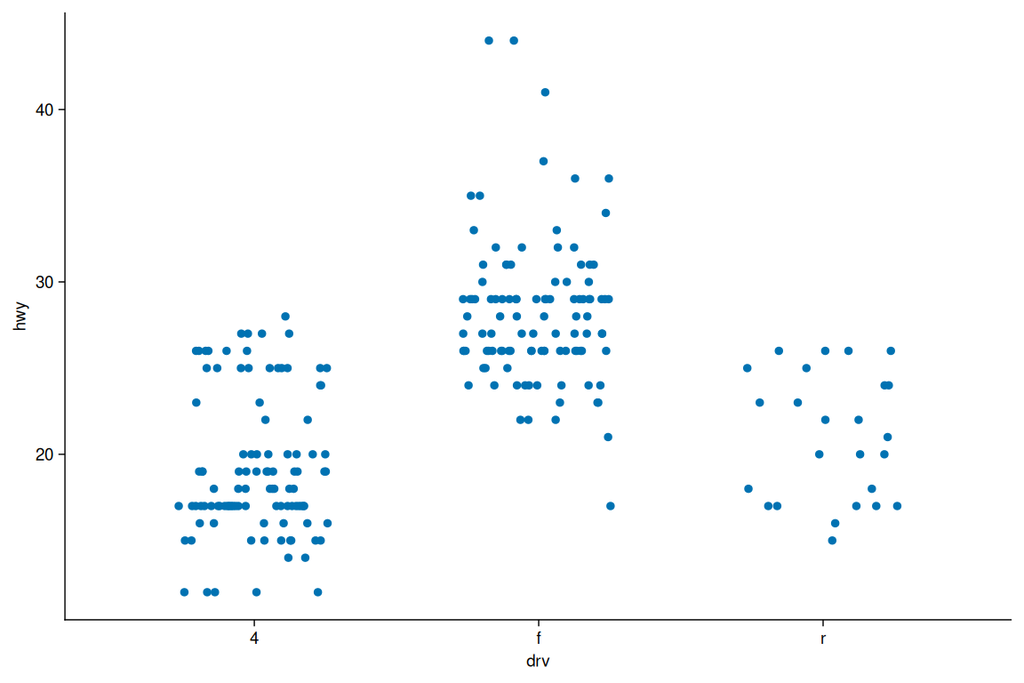

## Boxplot — ggplot2

```r
ggplot(mpg, aes(drv, hwy)) + geom_boxplot()
```

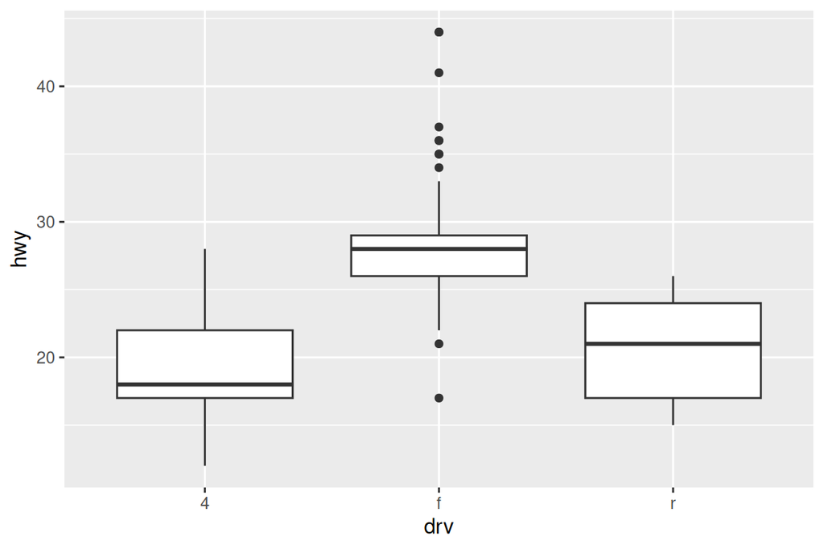

## Boxplot — tidyplots

```r
mpg |>
  tidyplot(x = drv, y = hwy, width = NA, height = NA) |>
  add_boxplot()
```

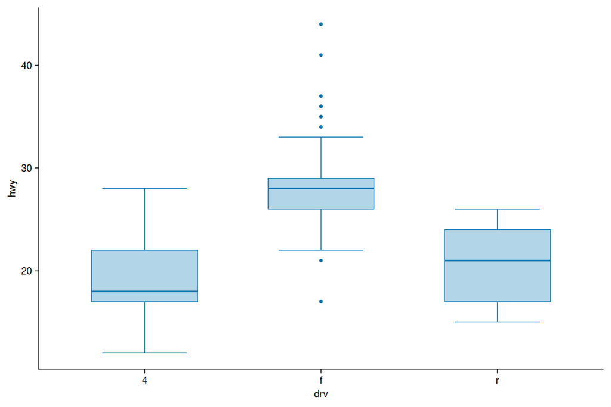

## Violin — ggplot2

```r
ggplot(mpg, aes(drv, hwy)) + geom_violin()
```

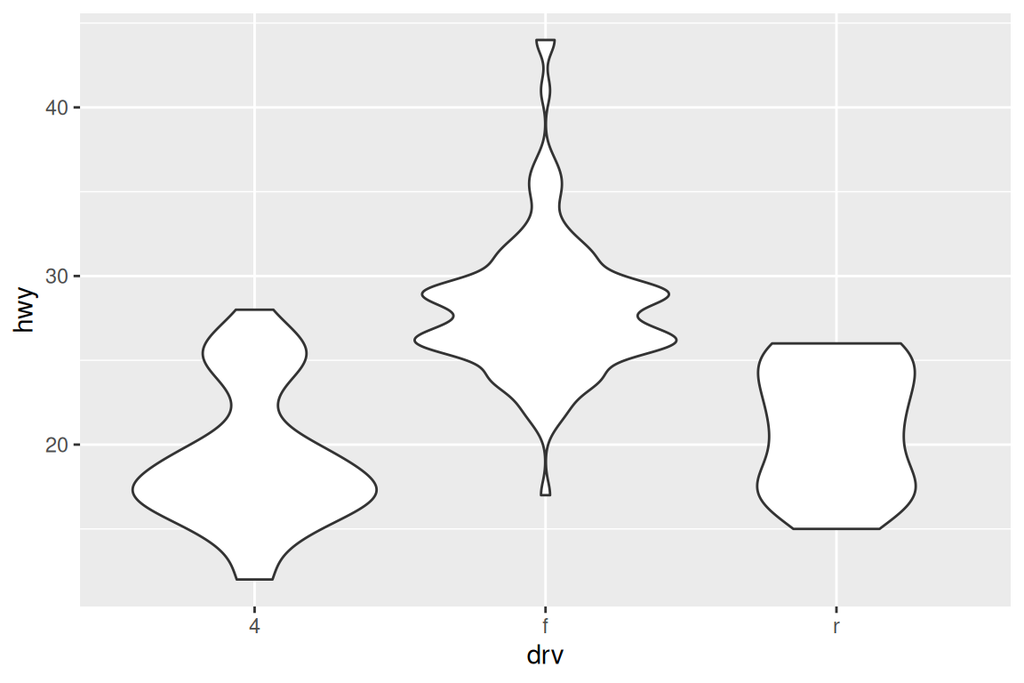

## Violin — tidyplots

```r
mpg |>
  tidyplot(x = drv, y = hwy, width = NA, height = NA) |>
  add_violin()
```

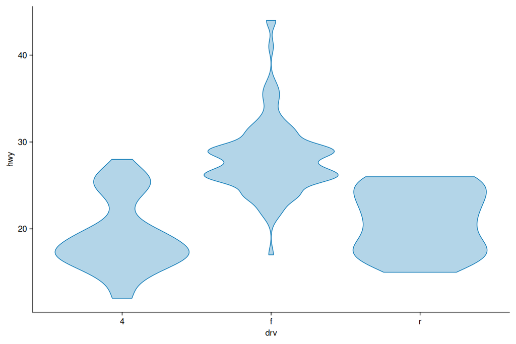

## Histogram — ggplot2

```r
ggplot(mpg, aes(hwy)) + geom_histogram()
```

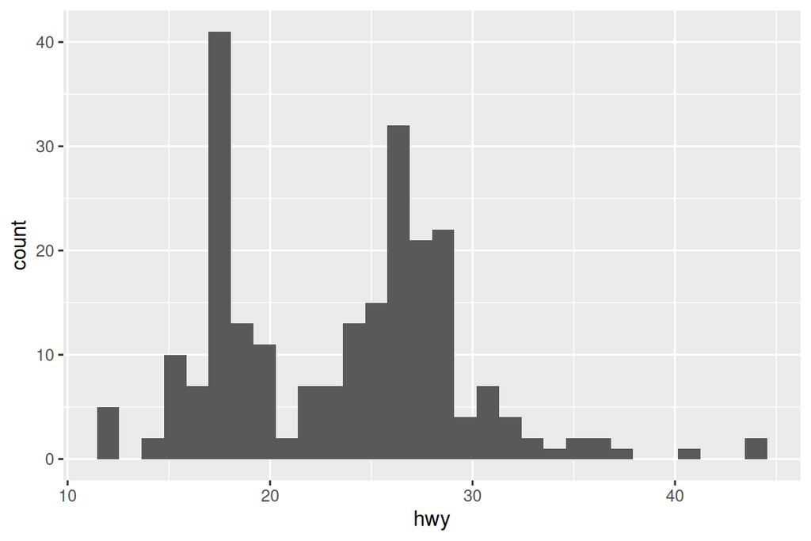

## Histogram — tidyplots

```r
mpg |>
  tidyplot(x = hwy, width = NA, height = NA) |>
  add_histogram()
```

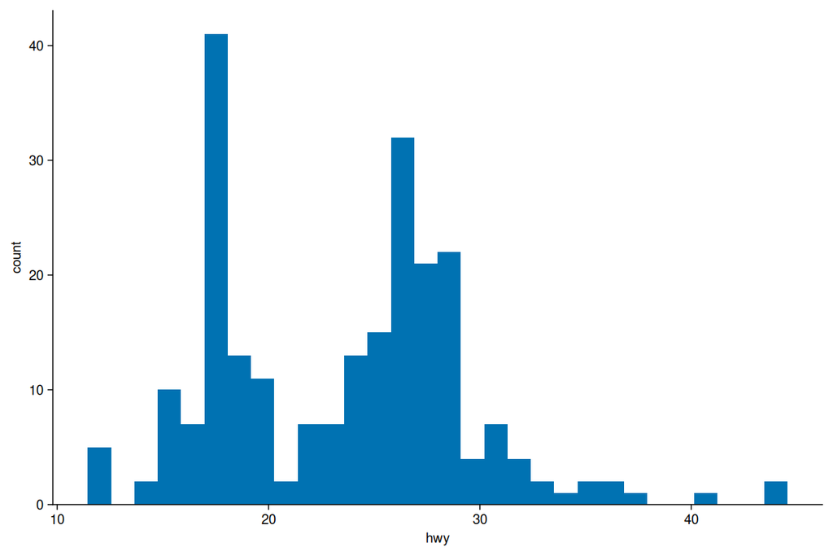